# CODGames

Brian Ellis

2023-03-04

## Front Matter

```r
rm(list = ls())
# Load libraries
library(tidyverse)
library(readxl)
library(lubridate)
```

## Task 1

1. Read the dataset into R. • We have not covered methods for reading an .xlsx file into R. • Yes, you could save as .csv but that risks potential data loss. • It would be better to search for a method (R function) that allows you to open .xlsx files in R.

```r
# Read dataset
COD <- read_excel("~/Downloads/CODGames2_mp.xlsx")
head(COD)
```

```
## # A tibble: 6 × 27
##   Map1  Map2  Choice MapVote Date                FullPartial Result Eliminations
##   <chr> <chr> <chr>  <chr>   <dttm>              <chr>       <chr>         <dbl>
## 1 Mosc… Miam… Miami… 5 to 0  2022-06-06 00:00:00 Full        100-97           22
## 2 Mosc… WMD   Moscow 2 to 0  2022-06-06 00:00:00 Full        76-89            20
## 3 <NA>  <NA>  Yaman… <NA>    2022-06-06 00:00:00 Full        100-92           18
## 4 Driv… Jung… Drive… 2 to 0  2022-06-06 00:00:00 Full        80-100           10
## 5 Coll… Hija… Colla… 3 to 3  2022-06-06 00:00:00 Full        71-100           11
## 6 Cros… Raid  Raid   4 to 3  2022-06-06 00:00:00 Full        85-100            7
## # … with 19 more variables: Deaths <dbl>, Score <dbl>, Damage <dbl>,
## #   TotalXP <dbl>, PrimaryWeapon <chr>, XPType <chr>, DidPlayerVote <chr>,
## #   GameType <chr>, Confirms <dbl>, Denies <dbl>, Objectives <dbl>,
## #   ObjectiveKills <dbl>, Captures <dbl>, Diffuses <lgl>, Plants <lgl>,
## #   Detonates <lgl>, Deposits <lgl>, Time_Sec <dbl>, Time_Min <dbl>
```

## Task 2- Explore 6 variables

2. Begin to explore the dataset. Explore 6 variables of your choice. (You should explore at least one categorical and at least one quantitative variable.) • For each, you should identify the variable, the type of variable (categorical, quantitative, etc.), information about the types of values the variable can take, and the amount of missing data within the variable. • For each variable, report some summary statistics and make a visualization. o If a variable is categorical, make a table of possible values and include counts or proportions. Then, make an appropriate plot to show the distribution of values. o If a variable is quantitative, include some basic summary stats like the mean, median, standard deviation, min, max, etc. and make an appropriate plot to show the distribution of values. • For each variable, you should write a few sentences to describe what you have learned about the variable. Remember, the goal is not to make the plot/calculate the summaries. The goal is to use plots and summaries to gain knowledge from the data.

The first variable I will explore is the ‘Result’ variable.

```r
# List variable and data types
glimpse(head(COD$Result))
```

```
##  chr [1:6] "100-97" "76-89" "100-92" "80-100" "71-100" "85-100"
```

```r
sum(is.na(COD$Result))
```

```
## [1] 0
```

‘Result’ is a categorical variable even though it mainly contains integers. The values of the variable contain two sets of integer values, one the winning teams score (usually 100) and the other the losing team’s score. This variable contains 0 missing values.

```r
# Table of possible values of 'Results'
table(COD$Result)
```

```
##
##  100-48  100-51  100-54  100-55  100-56  100-60  100-61  100-62  100-63  100-65
##       1       1       1       1       1       1       1       1       1       1
##  100-66  100-67  100-68  100-69  100-70  100-71  100-72  100-74  100-75  100-76
##       1       1       1       2       3       3       1       1       3       1
##  100-77  100-78  100-79  100-80  100-82  100-83  100-84  100-85  100-86  100-87
##       2       3       2       1       2       4       4       6       3       1
##  100-88  100-89  100-90  100-91  100-92  100-93  100-94  100-95  100-96  100-97
##       3       1       5       2       5       4       4       1       5       1
##  100-98  100-99 112-250 117-200 140-200 200-200 214-250 226-250 250-143 250-207
##       4       3       1       1       1       1       1       1       1       1
## 250-210  250-54  250-94   46-65   47-65   48-97  51-100  52-100  53-100   53-62
##       1       1       1       1       1       1       1       1       2       1
##  55-100  56-100  58-100   58-79  59-100  60-100   60-75   60-99  63-100  64-100
##       1       1       1       1       2       1       1       1       1       1
##  65-100   65-52   66-85   66-91  67-100  68-100  69-100  70-100  71-100  72-100
##       2       1       1       1       2       1       1       2       3       1
##  73-100   73-97  74-100   74-65  75-100  76-100   76-89  77-100   77-87   77-98
##       1       1       2       1       2       1       1       1       1       1
##  78-100   78-78  79-100   79-95  80-100   80-91  81-100   82-98  83-100  84-100
##       2       1       2       1       1       1       3       1       3       2
##   84-74  85-100  86-100  87-100   87-99  88-100   88-82   88-83  89-100  90-100
##       1       4       2       3       1       1       1       1       1       2
##  91-100   91-57   91-86  92-100   92-84  93-100   93-72  94-100   94-70   94-88
##       1       1       2       1       1       1       1       3       1       1
##  95-100   95-94   95-96  96-100   96-91  97-100   97-88  98-100  99-100   99-81
##       2       1       1       1       1       3       1       1       1       1
##   99-99
##       1
```

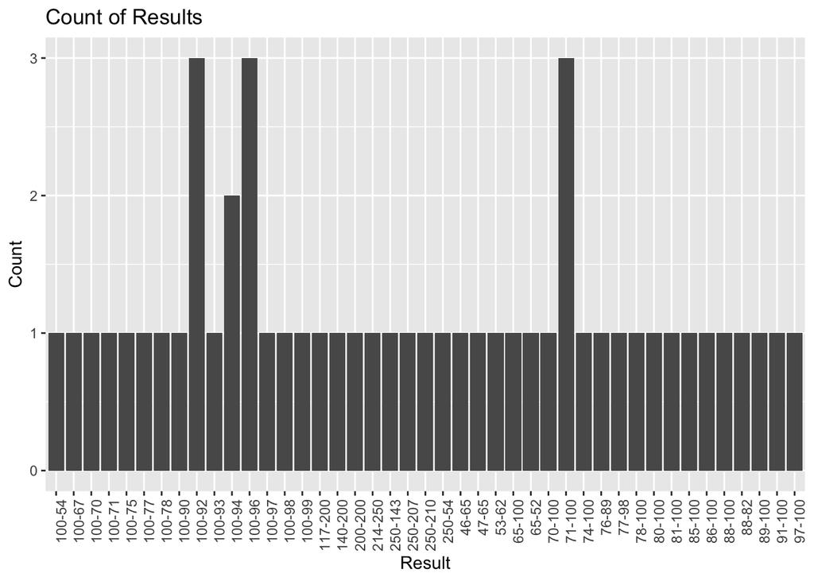

```r
# Visualization of 'Results'
COD %>%
  head(50) %>%  # I use the head function here because plotting the entire dataset is a visual mess and doesn't add any value
  ggplot(aes(x = Result)) +
  geom_bar() +
  labs(title = "Count of Results",
       x = "Result",
       y = "Count") +
  theme(axis.text.x = element_text(angle = 90, hjust = 1))
```

The second variable I will explore is ‘Score’

```r
# List variable and data types
glimpse(head(COD$Score))
```

```
##  num [1:6] 4070 5305 3335 2170 2195 ...
```

```r
sum(is.na(COD$Score))
```

```
## [1] 0
```

‘Score’ is a quantitative variable and contains 0 missing values. The values of the variable indicate the score from a match which is probably dependent on several other variables from this dataset.

```r
# Include summary statistics
summary(COD$Score)
```

```
##    Min. 1st Qu.  Median    Mean 3rd Qu.    Max.
##     100    1982    2770    2945    3582    7315
```

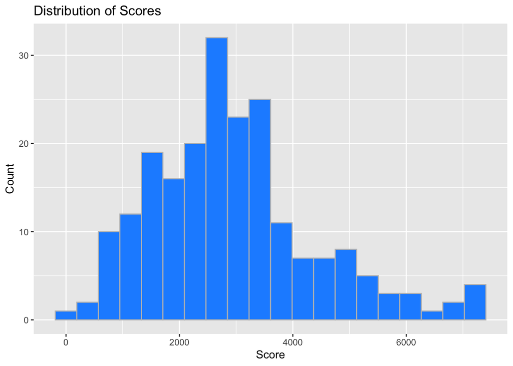

```r
# Visualization of variable
COD %>%
  ggplot(aes(x = Score)) +
  geom_histogram(bins = 20, fill = "dodgerblue", color = "grey") +
  labs(title = "Distribution of Scores",
       x = "Score",
       y = "Count")
```

From doing this initial exploration of the ‘Score’ variable, we can see that it is a continuous quantitative variable that ranges from around 100-7000. Both the median and the mode lay just under 3000 so that seems like the average value of score. Looking at the histogram plotted, the distribution of scores seems to be a little right-skewed which would mean that infrequent high scores are possible.

The third variable I will explore is ‘PrimaryWeapon’

```r
# List variable and data types
glimpse(head(COD$PrimaryWeapon))
```

```
##  chr [1:6] "M16" "M16" "M16" "M16" "M16" "M16"
```

```r
sum(is.na(COD$PrimaryWeapon))
```

```
## [1] 0
```

The variable ‘PrimaryWeapon’ is a categorical variable with 0 missing values. It looks like this variable lists the primary gun used by the player in a match. It would be interesting to see the effect this variable has on several factors such as ‘Score’.

```r
# Table of possible values of 'PrimaryWeapon'
table(COD$PrimaryWeapon)
```

```
##
##         AK-47        FFAR 1        Krig 6           M16         MG 82
##             4             3            21            48             2
##           MP5 Pelington 703        QBZ-83       Type 63
##            45            38            37            13
```

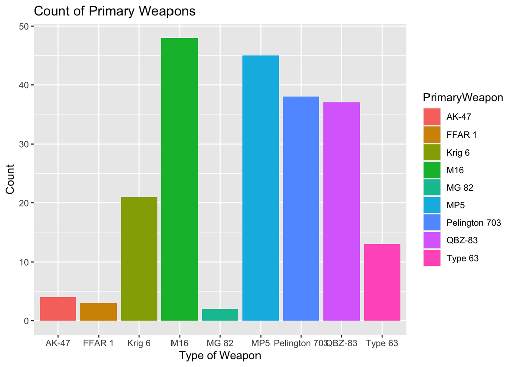

```r
# Visualize distribution
COD %>%
  ggplot(aes(x = PrimaryWeapon)) +
  geom_bar(aes(fill = PrimaryWeapon)) +
  labs(title = "Count of Primary Weapons",
       x = "Type of Weapon",
       y = "Count")
```

After looking at this table and visualization, it seems like there are a few favorite weapons of the players in this dataset. There are about 4 weapons that dominate the share of the distribution while the others show up infrequently. It would be nice to correlate the scores of players with their weapon choice so as to justify the use of a certain kind of weapon.

The fourth variable I will explore is ‘Eliminations’

```r
# List variable and data types
glimpse(head(COD$Eliminations))
```

```
##  num [1:6] 22 20 18 10 11 7
```

```r
sum(is.na(COD$Eliminations))
```

```
## [1] 0
```

The variable is quantitative and has 0 missing values. It looks like it is the number of total kills a player has in a match.

```r
# Include summary statistics
summary(COD$Eliminations)
```

```
##    Min. 1st Qu.  Median    Mean 3rd Qu.    Max.
##    2.00   11.00   14.00   15.09   18.50   39.00
```

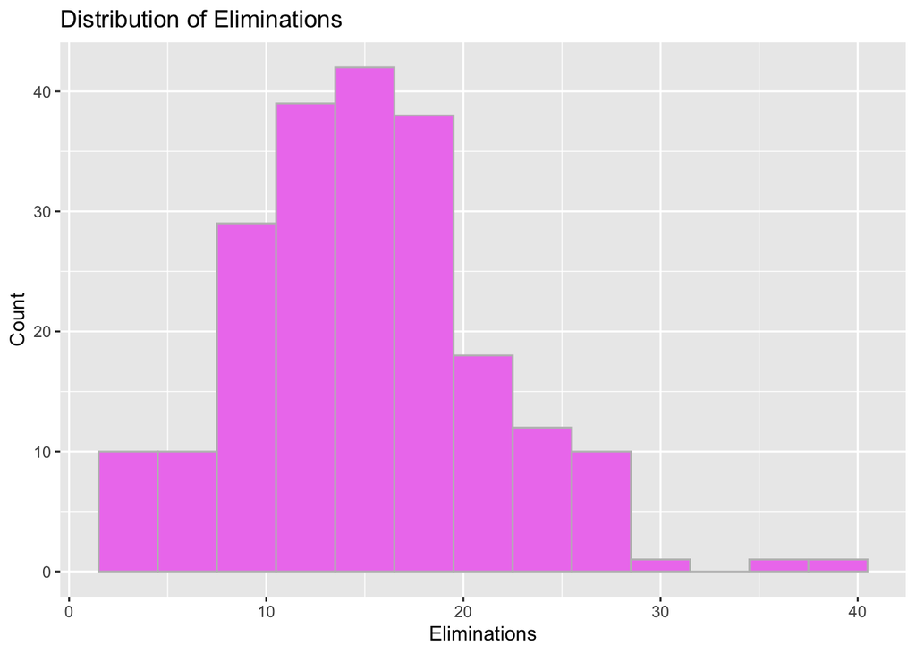

```r
# Visualization of variable
COD %>%
  ggplot(aes(x = Eliminations)) +
  geom_histogram(binwidth = 3, fill = "violet", color = "grey") +
  labs(title = "Distribution of Eliminations",
       x = "Eliminations",
       y = "Count")
```

This variable has a similar distribution and spread to the ‘Score’ variable which leads me to believe these two variables are highly correlated. We see the majority of elimination totals around 15 with a few outliers in the higher range.

```r
cor(COD$Score, COD$Eliminations)
```

```
## [1] 0.8362981
```

We can confirm the correlation above, the two variables have a correlation of 0.836.

The fifth variable I will explore is ‘Deaths’

```r
# List variable and data types
glimpse(head(COD$Deaths))
```

```
##  num [1:6] 17 15 11 19 19 18
```

```r
sum(is.na(COD$Deaths))
```

```
## [1] 0
```

The variable is quantitative and has 0 missing values. It looks like it is the number of total number of deaths a player has in a match.

```r
# Include summary statistics
summary(COD$Deaths)
```

```
##    Min. 1st Qu.  Median    Mean 3rd Qu.    Max.
##    4.00   12.00   15.00   14.98   17.50   42.00
```

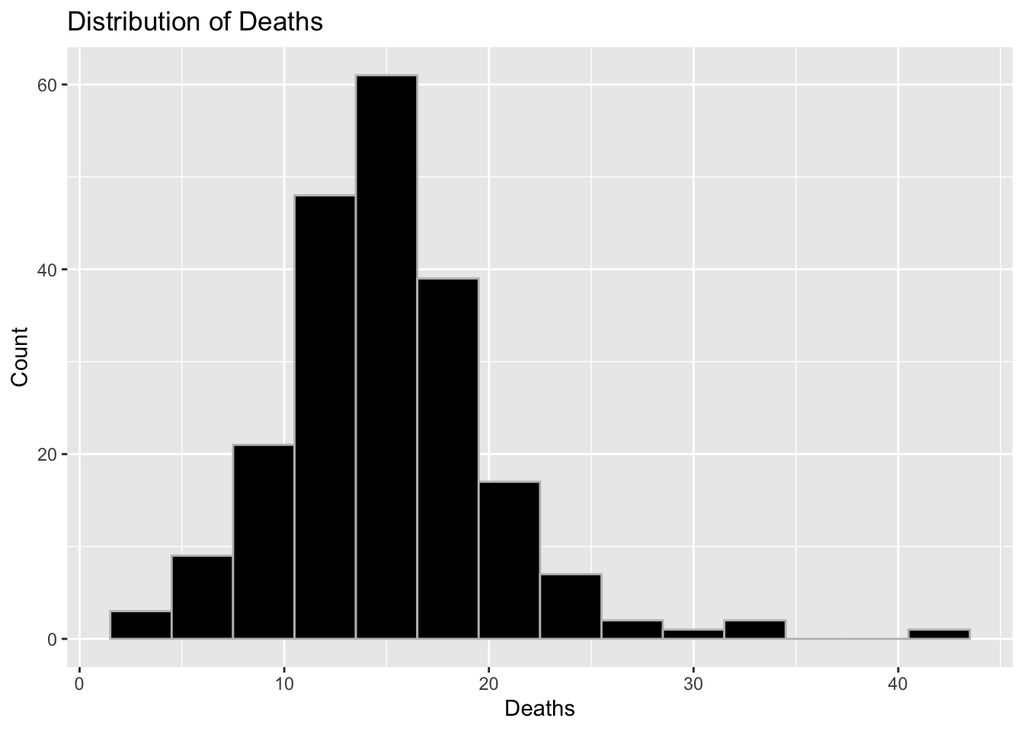

```r
# Visualization of variable
COD %>%
  ggplot(aes(x = Deaths)) +
  geom_histogram(binwidth = 3, fill = "black", color = "grey") +
  labs(title = "Distribution of Deaths",
       x = "Deaths",
       y = "Count")
```

‘Deaths’ seems to be normally distributed with a mean and median hovering around 15. Just like ‘Eliminations’, I feel this variable is highly correlated with ‘Score’ and it would be interesting to plot their relationships.

The sixth variable I will explore is ‘Damage’

```r
# List variable and data types
glimpse(head(COD$Damage))
```

```
##  num [1:6] 634 560 483 280 308 196
```

```r
sum(is.na(COD$Damage))
```

```
## [1] 0
```

‘Damage’ is a quantitative variable with 0 missing values. The values of this variable seem to be the damage a player takes or inflicts in a match.

```r
# Include summary statistics
summary(COD$Damage)
```

```
##    Min. 1st Qu.  Median    Mean 3rd Qu.    Max.
##    56.0   303.5   397.0   415.2   508.0   960.0
```

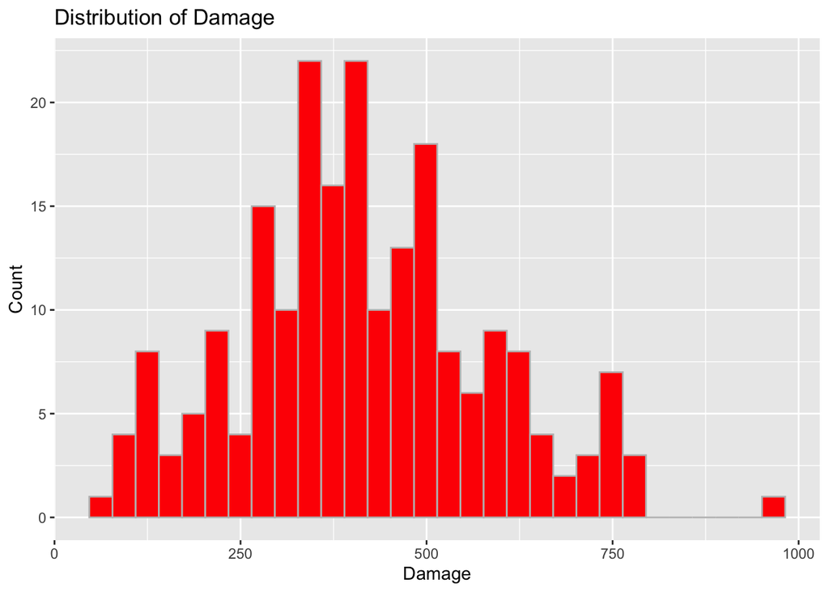

```r
# Visualization of variable
COD %>%
  ggplot(aes(x = Damage)) +
  geom_histogram(fill = "red", color = "grey") +
  labs(title = "Distribution of Damage",
       x = "Damage",
       y = "Count")
```

‘Damage’ seems to be normally distributed with an average around 400. I would be interested to see the relationship this variable shares with ‘PrimaryWeapon’ as to see if a particular weaopn leads to higher damage.

## Task 3

Begin a list of questions that you have about the dataset. Suppose you are working on a project and your manager gives you this dataset. Write 3 questions that you would ask your manager. • You have not been given any information about what the variables represent. So, if you are unsure about the meaning of any of the variables, write your questions. • You have not been given any information about how the data were collected. If you have questions about the data collection, write them down. • If you have any other questions, write them down. • NOTE: Even if you are familiar with the game and think that you understand the meaning of the variables, you are still expected to write 3 potential questions that you could ask.

- Some of the variables are unclear in their names, like what does ‘Damage’ represent? The damage a player inflicts in a match or the damage that they receive?
- It seems some of the variables need to be altered in order to get meaning from them, like ‘Result’ for instance should be mutated so as to make the variable more useful. Could we take the difference between the two numbers to make a more informative variable?
- From where is this data sourced? Is this a collection of many different player’s stats from a random time period, or a set time period? Is this one player’s stats or many different player’s stats?

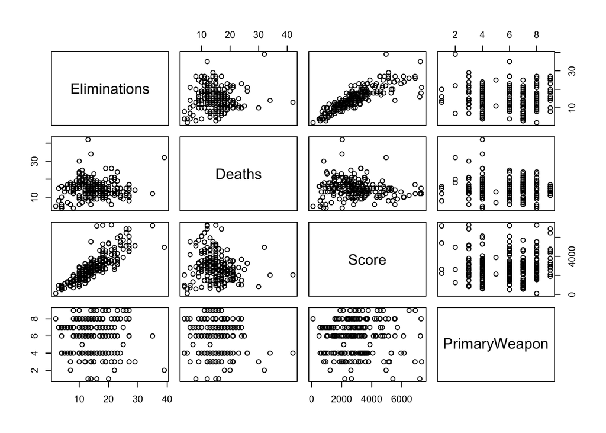

```r
hey <-
  COD %>%
  select(Eliminations, Deaths, Score, PrimaryWeapon)

plot(hey)
```

```r
mult <- lm(Score ~ Eliminations + Deaths + PrimaryWeapon, data = hey)
summary(mult)
```

```
##
## Call:
## lm(formula = Score ~ Eliminations + Deaths + PrimaryWeapon, data = hey)
##
## Residuals:
##     Min      1Q  Median      3Q     Max
## -1685.4  -429.5   -82.2   333.8  3707.7
##
## Coefficients:
##                             Estimate Std. Error t value Pr(>|t|)
## (Intercept)                 1723.079    410.718   4.195 4.10e-05 ***
## Eliminations                 206.927      8.778  23.574  < 2e-16 ***
## Deaths                       -48.309     10.193  -4.739 4.06e-06 ***
## PrimaryWeaponFFAR 1        -2349.565    573.503  -4.097 6.08e-05 ***
## PrimaryWeaponKrig 6        -1116.940    401.302  -2.783 0.005897 **
## PrimaryWeaponM16           -1101.145    383.419  -2.872 0.004520 **
## PrimaryWeaponMG 82         -1954.685    636.682  -3.070 0.002437 **
## PrimaryWeaponMP5           -1339.487    383.500  -3.493 0.000588 ***
## PrimaryWeaponPelington 703 -1139.958    388.138  -2.937 0.003703 **
## PrimaryWeaponQBZ-83        -1150.868    386.748  -2.976 0.003283 **
## PrimaryWeaponType 63       -1156.071    420.824  -2.747 0.006560 **
## ---
## Signif. codes:  0 '***' 0.001 '**' 0.01 '*' 0.05 '.' 0.1 ' ' 1
##
## Residual standard error: 734.1 on 200 degrees of freedom
## Multiple R-squared:  0.7609, Adjusted R-squared:  0.7489
## F-statistic: 63.64 on 10 and 200 DF,  p-value: < 2.2e-16
```

## Task 4 Part 1

4. Asking a question that can be answered using the dataset and data visualization. • Part 1 – You will answer my question: Is the player’s performance, as quantified by the amount of experience points gained (TotalXP variable) changing over time? o To answer this, you should find a way to extract the month from the Date variable (we have not covered working with dates in STAT 380) o The lubridate package is useful for working with dates o Once you have the months, create side-by-side boxplots showing the TotalXP based on the Month, where the months are named (i.e., month should be June, not the number 6). The months should be in chronological order, not alphabetical order o Based on the plot, answer the question. If you have knowledge about these types of games, you can also mention other variables that could affect TotalXP but were not included in the question.

```r
# Extracting month and creating new variable
COD <-
  COD %>%
    mutate(Month = month(as.POSIXlt(Date, format = "%Y/%m/%d"))) %>%
  mutate(Month = month.name[Month])
```

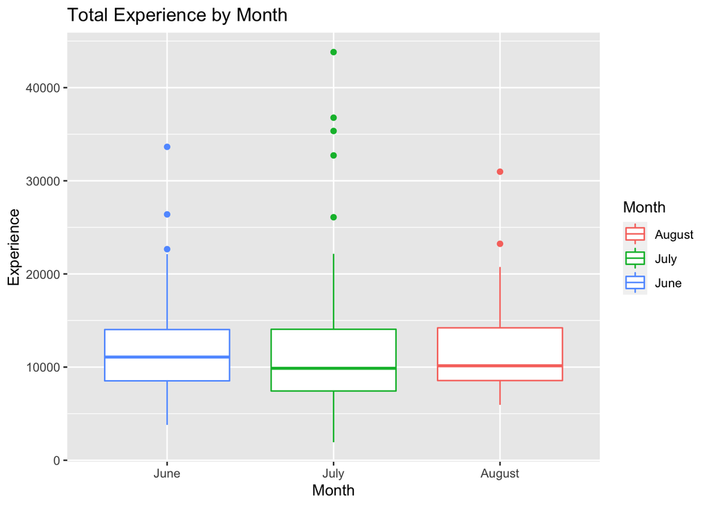

```r
# Side by Side boxplots
level_order <- c('June', 'July', 'August')

COD %>%
  ggplot(aes(x = factor(Month, levels = level_order), y = TotalXP, color = Month)) +
  geom_boxplot() +
  labs(title = "Total Experience by Month",
       x = "Month",
       y = "Experience")
```

There doesn’t seem to be a major discrepency between amount of experience gained over time as the IQRs of each boxplot overlay each other. This tells us that the player’s performance as quantified by total experience is not changing over time. We should include more variables into our analysis that would give us more information as to why the total experience is not displaying significant differences over time. Variables such as amount of data points/games played in each month or type of game mode played could significantly be affecting player experience.

## Task 4 Part 2

• Part 2 – You will write your own question, create a data visualization that can help answer your question, and write an answer to your question. The question/visualization should explore the relationship between at least 2 of the variables in the dataset. Be sure you include both the question and the answer to your question based on the visualization you have created.

The question I want to answer is, what immediate changes can the player make to improve his overall performance?

To do this, we will quantify performance by several variables that indicate higher ‘Score’. It would seem obvious that ‘TotalXP’ would be positvely correlated with ‘Score’.

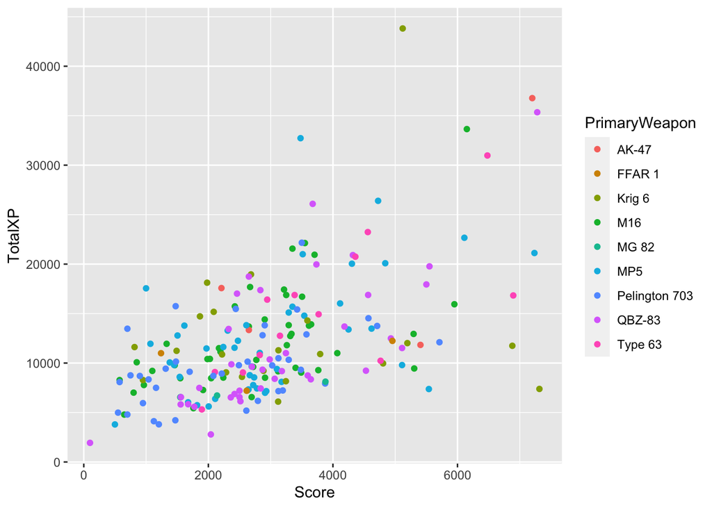

```r
# Visualizing TotalXP by Score
COD %>%
  ggplot(aes(x = Score, y = TotalXP, color = PrimaryWeapon)) +
  geom_point()
```

We’ll take a closer look at ‘PrimaryWeapon’ since it can be the source of an immediate change - the player can switch weapons every time they load into a new game.

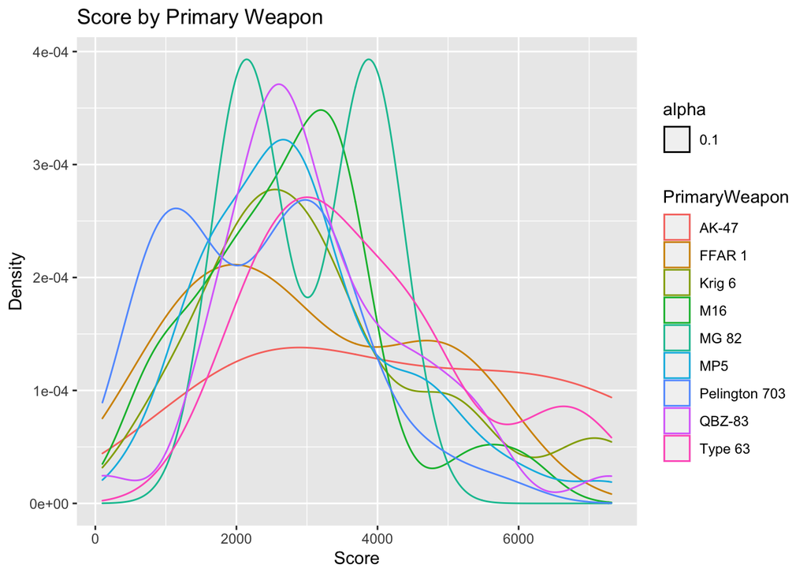

```r
COD %>%
  ggplot(aes(x = Score, group = PrimaryWeapon, color = PrimaryWeapon, alpha = 0.1)) +
  geom_density() +
  labs(title = "Score by Primary Weapon",
       x = "Score",
       y = "Density")
```

From this density plot there doesn’t seem to be a convincingly dominant weapon that would prove the best change although AK-47 seems to give the player the widest distribution and the highest frequency of better scores.

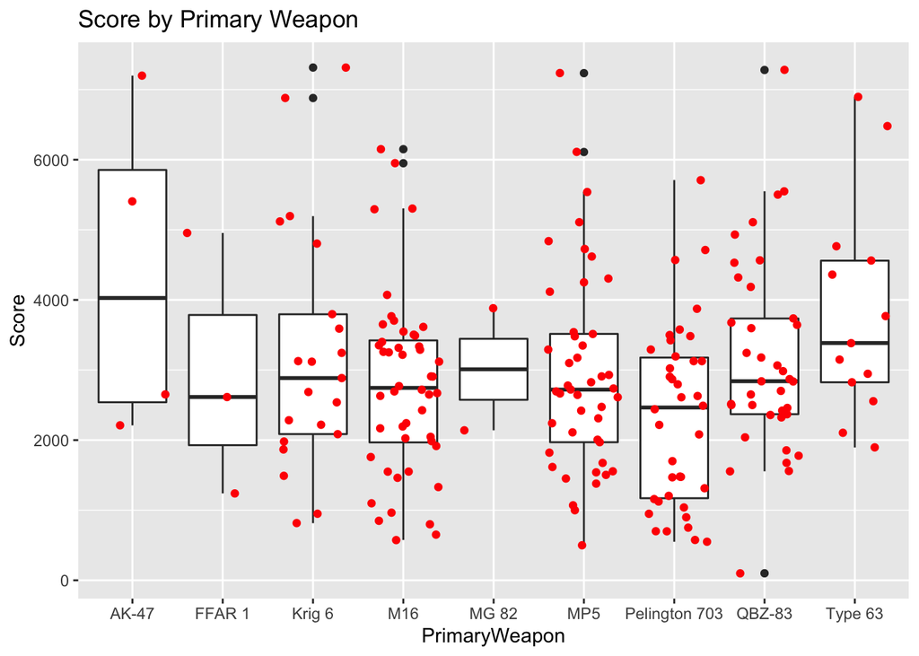

```r
COD %>%
  ggplot(aes(x = PrimaryWeapon, y = Score)) +
  geom_boxplot() +
  geom_point(color = "red", position = "jitter") +
  labs(title = "Score by Primary Weapon")
```

This boxplot allows us to get a better visual of the frequency and discrepency amongst the weapons. Although it looked like AK-47 provided the player with the highest scores on average, we can see there are very few games played with the weapon so that data can be misleading. It looks like the gun Type 63 could be a better performing gun for the player.

Earlier we saw how the player’s performance measured by ‘TotalXP’ didn’t seem to be changing over time, but what about the type of guns they used?

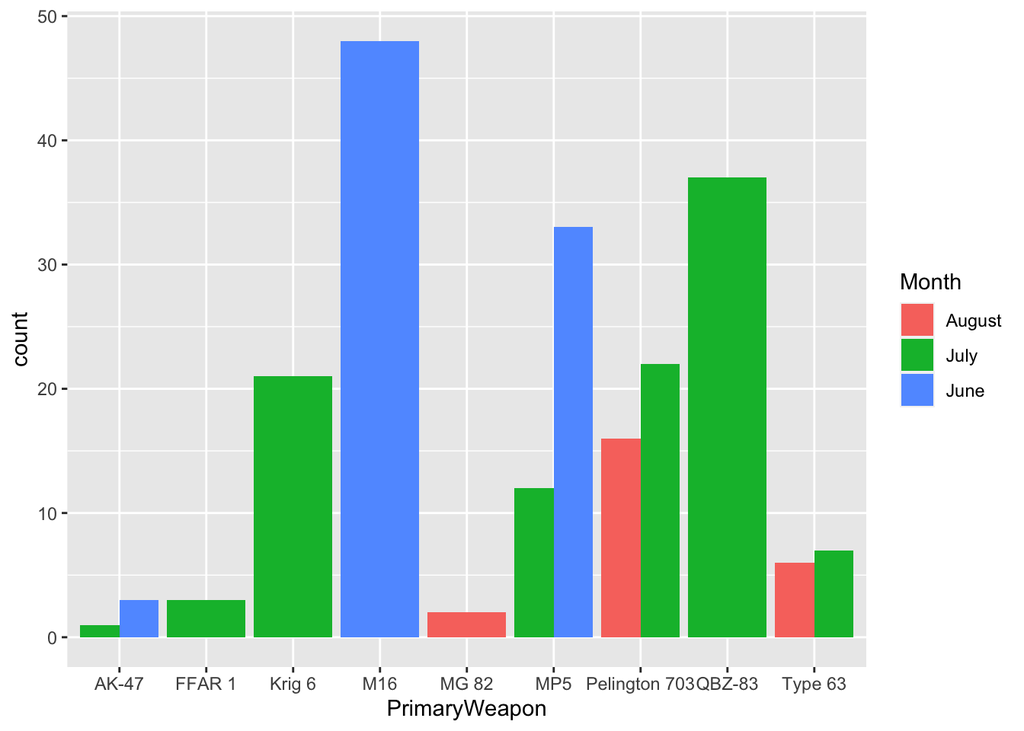

```r
COD %>%
  ggplot(aes(x = PrimaryWeapon)) +
  geom_bar(aes(fill = Month), position = "dodge")
```

There seems to be some interesting discoveries here. There are several guns that were only used in a particular month, indicating the player uses one gun consistently for a certain period of time before moving onto the next gun.

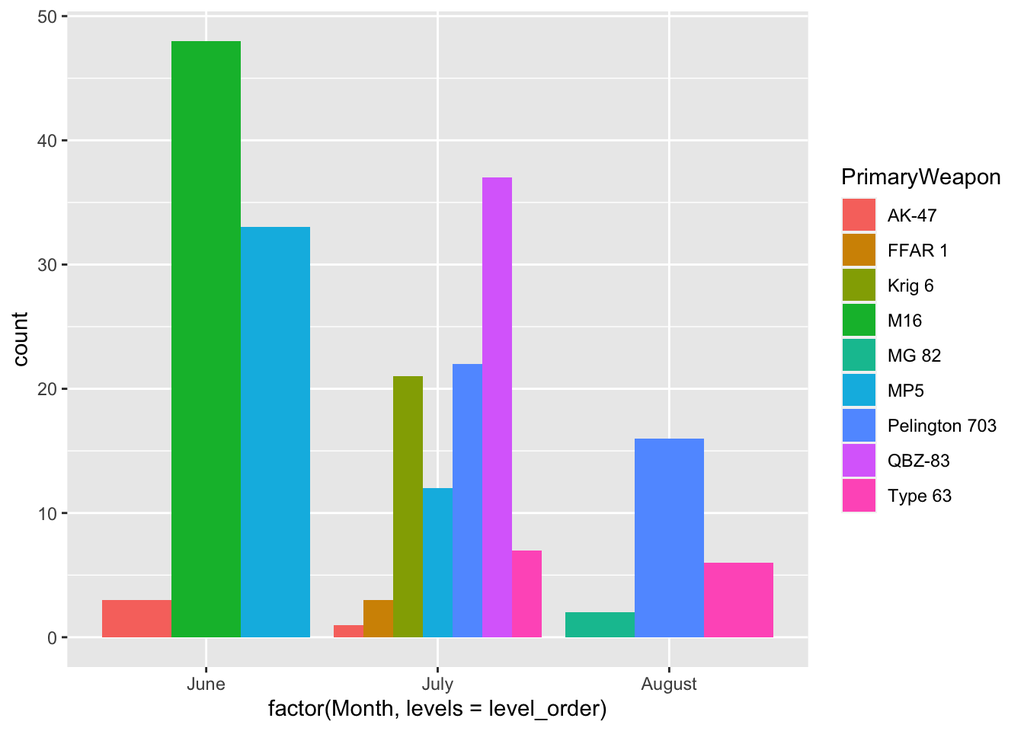

```r
COD %>%
  ggplot(aes(x = factor(Month, levels = level_order))) +
  geom_bar(aes(fill = PrimaryWeapon), position = "dodge")
```

If we plot the ‘Month’ variable on the x-axis, we see that the player is definitely changing their weapon of choice over time. Here we see a trend towards using more of the Pelington 703 and Type 63 as time goes on. Judging from the earlier boxplots, the player should keep using Type 63 but try switching the Pelington 703 for another weapon because of its poor performance, maybe the Ak-47 again.

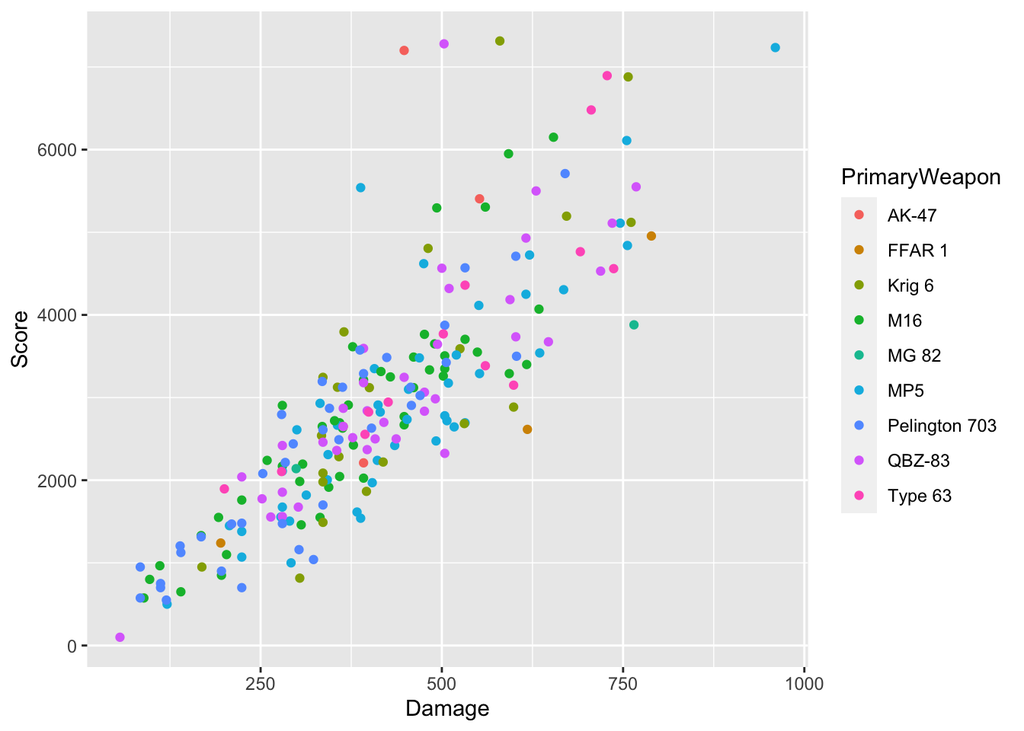

```r
COD %>%
  ggplot(aes(x = Damage, y = Score, color = PrimaryWeapon)) +
  geom_point()
```

There’s a strong positive correlation between Damage and Score.

```r
cor(COD$Damage, COD$Score)
```

```
## [1] 0.8376413
```

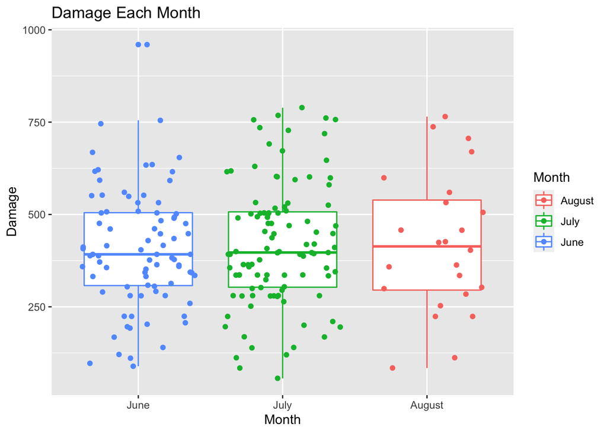

```r
# Plotting damage over time
COD %>%
  ggplot(aes(x = factor(Month, levels = level_order), y = Damage, color = Month)) +
  geom_boxplot() +
  geom_point(position = "jitter") +
  labs(title = "Damage Each Month",
       x = "Month",
       y = "Damage")
```

```r
# Maps that give the most score
COD %>%
  group_by(Choice) %>%
  summarize(N = n(),
            TotalScore = sum(Score),
            AvgScore = TotalScore / n()) %>%
  arrange(desc(AvgScore)) %>%
  head(10)
```

```
## # A tibble: 10 × 4
##    Choice                N TotalScore AvgScore
##    <chr>             <int>      <dbl>    <dbl>
##  1 Moscow                5      18400    3680
##  2 The Pines             5      17990    3598
##  3 Apocalypse            7      25180    3597.
##  4 Amerika               3      10480    3493.
##  5 Diesel               15      51660    3444
##  6 Express               7      24060    3437.
##  7 Nuketown '84          9      30620    3402.
##  8 Standoff             12      38986    3249.
##  9 Collateral Strike    12      38700    3225
## 10 Drive-In             11      34995    3181.
```

```r
# Maps that give the lowest score
COD %>%
  group_by(Choice) %>%
  summarize(N = n(),
            TotalScore = sum(Score),
            AvgScore = TotalScore / n()) %>%
  arrange(AvgScore) %>%
  head(10)
```

```
## # A tibble: 10 × 4
##    Choice                N TotalScore AvgScore
##    <chr>             <int>      <dbl>    <dbl>
##  1 Jungle                4       4595    1149.
##  2 WMD                   6      12055    2009.
##  3 Hijacked              7      14505    2072.
##  4 <NA>                  1       2140    2140
##  5 Echelon               4       8770    2192.
##  6 Checkmate             7      16605    2372.
##  7 Rush                 15      38875    2592.
##  8 Garrison              8      21290    2661.
##  9 Crossroads Strike    15      40035    2669
## 10 Zoo                  10      26845    2684.
```

```r
lmChoice <- lm(Score ~ Choice, data = COD)
summary(lmChoice)
```

```
##
## Call:
## lm(formula = Score ~ Choice, data = COD)
##
## Residuals:
##     Min      1Q  Median      3Q     Max
## -2481.4  -953.0   -44.0   602.6  4643.3
##
## Coefficients:
##                         Estimate Std. Error t value Pr(>|t|)
## (Intercept)              3493.33     847.36   4.123 5.65e-05 ***
## ChoiceApocalypse          103.81    1012.79   0.102   0.9185
## ChoiceCartel             -477.62    1012.79  -0.472   0.6378
## ChoiceCheckmate         -1121.19    1012.79  -1.107   0.2697
## ChoiceCollateral Strike  -268.33     947.38  -0.283   0.7773
## ChoiceCrossroads Strike  -824.33     928.24  -0.888   0.3757
## ChoiceDeprogram          -615.33    1071.83  -0.574   0.5666
## ChoiceDiesel              -49.33     928.24  -0.053   0.9577
## ChoiceDrive-In           -311.97     955.95  -0.326   0.7445
## ChoiceEchelon           -1300.83    1120.95  -1.160   0.2474
## ChoiceExpress             -56.19    1012.79  -0.055   0.9558
## ChoiceGarrison           -832.08     993.62  -0.837   0.4034
## ChoiceHijacked          -1421.19    1012.79  -1.403   0.1622
## ChoiceJungle            -2344.58    1120.95  -2.092   0.0378 *
## ChoiceMiami Strike       -548.33    1037.80  -0.528   0.5979
## ChoiceMoscow              186.67    1071.83   0.174   0.8619
## ChoiceNuketown '84        -91.11     978.45  -0.093   0.9259
## ChoiceRaid               -504.17     947.38  -0.532   0.5952
## ChoiceRush               -901.67     928.24  -0.971   0.3326
## ChoiceSlums              -365.00     978.45  -0.373   0.7095
## ChoiceStandoff           -244.50     947.38  -0.258   0.7966
## ChoiceThe Pines           104.67    1071.83   0.098   0.9223
## ChoiceWMD               -1484.17    1037.80  -1.430   0.1544
## ChoiceYamantau           -458.33     978.45  -0.468   0.6400
## ChoiceZoo                -808.83     966.14  -0.837   0.4036
## ---
## Signif. codes:  0 '***' 0.001 '**' 0.01 '*' 0.05 '.' 0.1 ' ' 1
##
## Residual standard error: 1468 on 185 degrees of freedom
##   (1 observation deleted due to missingness)
## Multiple R-squared:  0.1145, Adjusted R-squared:  -0.0003602
## F-statistic: 0.9969 on 24 and 185 DF,  p-value: 0.4726
```

From these results, we see that the map ‘Jungle’ should be avoided by the player due to its significantly low score. If that map ends up being chosen, the player should exit the match and queue into a different game.

```r
# Gun chosen per map
COD %>%
  group_by(PrimaryWeapon) %>%
  summarize(N = n(),
            AvgDamage = sum(Damage) / N,
            AvgScore = sum(Score) / N) %>%
  arrange(desc(AvgScore)) %>%
  head(10)
```

```
## # A tibble: 9 × 4
##   PrimaryWeapon     N AvgDamage AvgScore
##   <chr>         <int>     <dbl>    <dbl>
## 1 AK-47             4      439     4366.
## 2 Type 63          13      519.    3822.
## 3 Krig 6           21      445.    3238.
## 4 QBZ-83           37      440.    3162.
## 5 MG 82             2      532     3010
## 6 MP5              45      447.    2943.
## 7 FFAR 1            3      534     2937.
## 8 M16              48      382.    2773.
## 9 Pelington 703    38      324.    2335.
```

One other variable that is under the player’s control is what game mode they choose to play in.

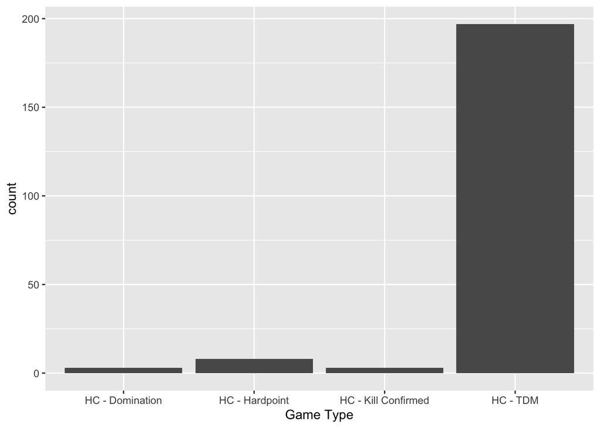

```r
COD %>%
  ggplot(aes(x = GameType)) +
  geom_bar() +
  labs(x = "Game Type")
```

The player heavily favors Team Deathmatch, but is it his best performing game type?

```r
COD %>%
  group_by(GameType) %>%
  summarize(N = n(),
            AvgScore = sum(Score) / N,
            AvgElim = sum(Eliminations) / N) %>%
  arrange(desc(AvgScore))
```

```
## # A tibble: 4 × 4
##   GameType                N AvgScore AvgElim
##   <chr>               <int>    <dbl>   <dbl>
## 1 HC - Domination         3    3363.    18.7
## 2 HC - TDM              197    2972.    15.0
## 3 HC - Hardpoint          8    2431.    16.4
## 4 HC - Kill Confirmed     3    2117.    12.7
```

His best performing game type is Domination, but with only 3 games played it doesn’t give us enough confidence to be sure. One suggestion we can make is tell the player to play more Domination game types.

```r
lmWeapon <- lm(Score ~ PrimaryWeapon, data = COD)
summary(lmWeapon)
```

```
##
## Call:
## lm(formula = Score ~ PrimaryWeapon, data = COD)
##
## Residuals:
##     Min      1Q  Median      3Q     Max
## -3062.2 -1015.6  -143.4   757.1  4291.6
##
## Coefficients:
##                            Estimate Std. Error t value Pr(>|t|)
## (Intercept)                  4366.2      715.4   6.103 5.22e-09 ***
## PrimaryWeaponFFAR 1         -1429.6     1092.8  -1.308  0.19228
## PrimaryWeaponKrig 6         -1128.6      780.5  -1.446  0.14976
## PrimaryWeaponM16            -1592.8      744.6  -2.139  0.03362 *
## PrimaryWeaponMG 82          -1356.2     1239.1  -1.095  0.27501
## PrimaryWeaponMP5            -1422.8      746.5  -1.906  0.05807 .
## PrimaryWeaponPelington 703  -2031.0      752.1  -2.700  0.00751 **
## PrimaryWeaponQBZ-83         -1204.1      753.1  -1.599  0.11140
## PrimaryWeaponType 63         -543.9      818.1  -0.665  0.50687
## ---
## Signif. codes:  0 '***' 0.001 '**' 0.01 '*' 0.05 '.' 0.1 ' ' 1
##
## Residual standard error: 1431 on 202 degrees of freedom
## Multiple R-squared:  0.08249,    Adjusted R-squared:  0.04616
## F-statistic:  2.27 on 8 and 202 DF,  p-value: 0.02404
```

By making a linear model and showing the summary we can see a statistically significant result for the weapons AK-47 (the intercept), M16, and Pelington 703. In the case of AK-47, the model reports the highest scores and we would suggest that the player should utilize this weapon more. For weapons M16 and Pelington 703, the player showed significant decline in ‘Score’ which we can suggest to the player that they should stop using those two weapons if they want to increase their ‘Score’. The only drawback to this analysis is the lack of data points for the Ak-47, we saw in a previouse boxplot the sparsness of the data concerning the AK-47 which doesn’t give us a lot of confidence in our prediction that its usage will make a signficant increase in the players ‘Score’. Overall, by looking at a few variables that are under the player’s control, such as ‘Choice’, ‘PrimaryWeapon’, and ‘GameType’, we can suggest that the player takes the following actions to improve his overall performance as measured by ‘Score’:

- Utilize the Ak-47 and Type 63 weapons as Primary Weapons
- Play more Domination Game Types
- Avoid matches where the map ‘Jungle’ is chosen